# Exploratory Data Analysis

Author

“Kristin Lloyd”

```r
options(repos = c(CRAN = "https://cran.rstudio.com"))
install.packages("tidyverse")
install.packages("usmap")
install.packages("networkD3")
install.packages("coin")
library(tidyverse)
library(tidyr)
library(reshape2)
library(usmap)
library(networkD3)
library(coin)
library(dplyr)
library(ggplot2)
```

Let’s load my raw dataset and look at my indepdent labels.

```r
df <- read.csv("../Data/raw-data/Senators.csv")
head(df)
```

```
  first      last party state ideology_score  region year source likes shares
1  Alex   Padilla     D    CA         -0.375 Midwest 2023      X   104     28
2  Alex   Padilla     D    CA         -0.375 Midwest 2024      X    68     33
3  Alex   Padilla     D    CA         -0.375 Midwest 2023      X    92     20
4   Amy Klobuchar     D    MN         -0.283 Midwest 2023      X    18      9
5   Amy Klobuchar     D    MN         -0.283 Midwest 2022      X  1600    269
6   Amy Klobuchar     D    MN         -0.283 Midwest 2021      X   510     96
  views
1  4756
2  8176
3  6516
4  3985
5
6
                                                                                                                                                                                                                                                                   message
1                                                                                    Climate change isn't just harming the health of our planet––it's hurting our nation's infrastructure. I joined @SenBudget to discuss the need to invest in climate resilient systems.
2                                                               NEWS: Over $1 billion dollars from EPA is headed to CA's ports to build zero-emission infrastructure. This historic funding is a HUGE step forward in addressing climate change and improving air quality.
3                                                                        2023 was the hottest year on record on Earth. The science is clear: we can't wait to act on climate change. It's time for:  A clean energy transition Clean jobs Curbing greenhouse gas emissions
4 The climate crisis is happening now and we need to confront it with a sense of urgency. The same communities that have been historically disenfranchised are likely to experience a disproportionate share of the effects of climate change and environmental disasters.
5                                             Climate change isn’t happening sometime in the future—it’s happening NOW. But we can meet this moment. We can invest in clean energy and pave the way to a carbon neutral economy. Time to pass the Inflation Reduction Act.
6                                                                                                                                                                                                We can’t ignore it: climate change is the existential threat of our time.
  independent_label sentiment
1       opportunity         1
2       opportunity         1
3       opportunity         1
4       opportunity         1
5       opportunity         1
6       opportunity         1
```

I want to make sure all senators are accounted for, let’s look at senator by state.

```r
senator_summary <- df %>%
  mutate(full_name = paste(first, last)) %>%
  distinct(state, full_name, party) %>%
  arrange(state, full_name) %>%
  group_by(state) %>%
  summarise(
    Senators = paste(paste(full_name, paste0("(", party, ")"), sep = " "),
                     collapse = ", "),
    Count = n()
  ) %>%
  ungroup()

print(senator_summary, n = Inf)
```

```
# A tibble: 50 × 3
   state Senators                                    Count
   <chr> <chr>                                       <int>
 1 AK    Dan Sullivan (R), Lisa Murkowski (R)            2
 2 AL    Katie Britt (R), Tommy Tuberville (R)           2
 3 AR    John Boozman (R), Tommy Cotton (R)              2
 4 AZ    Mark Kelly (D), Ruben Gallego (D)               2
 5 CA    Adam Schiff (D), Alex Padilla (D)               2
 6 CO    John Hickenlooper (D), Michael Bennet (D)       2
 7 CT    Chris Murphy (D), Richard Blumenthal (D)        2
 8 DE    Chris Coons (D), Lisa Rochester (D)             2
 9 FL    Mark  Rubio (R), Rick Scott (R)                 2
10 GA    Jon Ossoff (D), Raphael Warnock (D)             2
11 HI    Brian  Schatz (D), Mazie Hirono (D)             2
12 IA    Chuck Grassley (R), Joni Ernst (R)              2
```

[output cut: 38 more lines]

Each state except for Ohio has two senators. Ohio currently has one senator because J.D. Vance stepped down to become the vice president. So we are analyzing 99 senators as of November 30th, 2024.

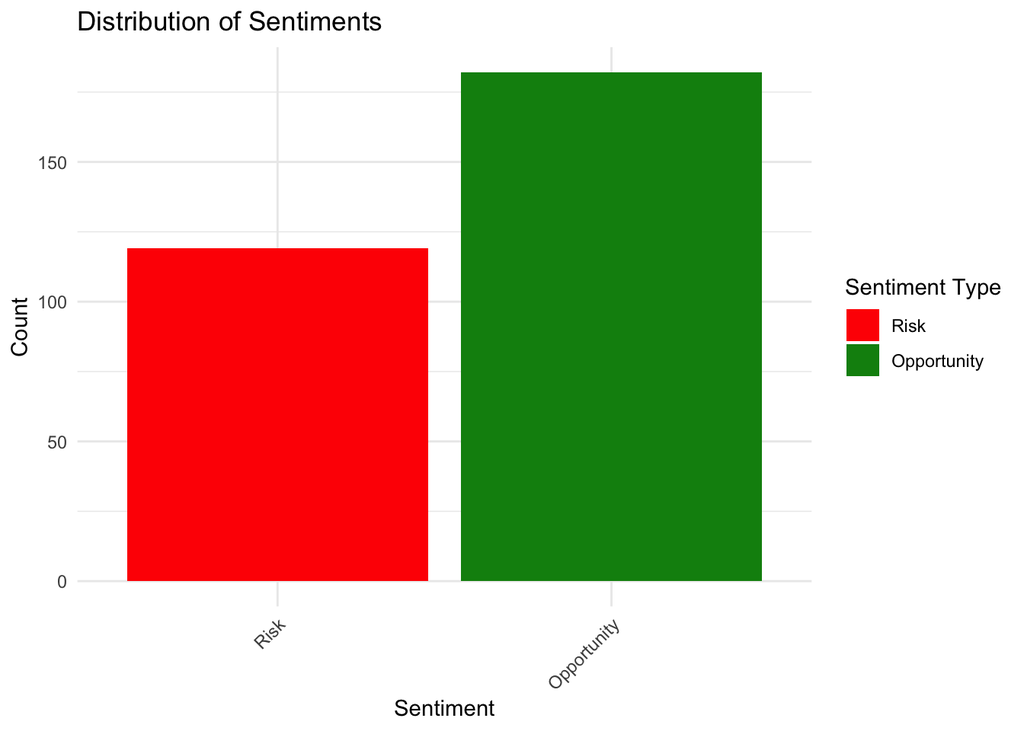

```r
independent_counts <- df %>%
  filter(!is.na(sentiment)) %>%
  count(sentiment)

independent_counts <- independent_counts %>%
  mutate(sentiment = factor(sentiment, levels = c(-1, 1), labels = c("Risk", "Opportunity")))

ggplot(independent_counts, aes(x = sentiment, y = n, fill = sentiment)) +
  geom_bar(stat = "identity") +
  scale_fill_manual(values = c("Risk" = "red", "Opportunity" = "#078d0f")) +
  labs(
    title = "Distribution of Sentiments",
    x = "Sentiment",
    y = "Count",
    fill = "Sentiment Type"
  ) +
  theme_minimal() +
  theme(axis.text.x = element_text(angle = 45, hjust = 1))
```

Let’s first look at how much risk and opportunity sentiment are in our dataset regarding climate change. Opportunity sentiment is more prevalent than risk sentiment, indicating that the senate generally has a proactive stance on addressing challenges and pursuing solutions. Now let’s look at a proportional distribution of sentiment by party.

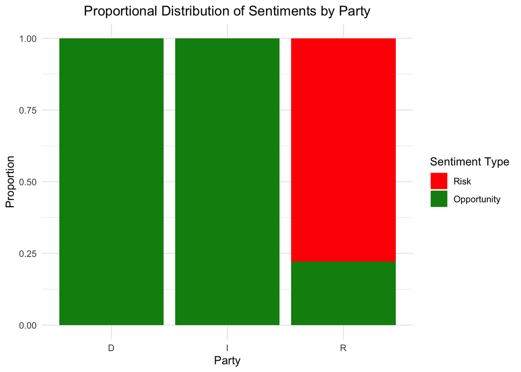

```r
grouped_data <- df %>%
  filter(!is.na(sentiment)) %>%
  group_by(party, sentiment) %>%
  summarise(Count = n(), .groups = 'drop') %>%
  group_by(party) %>%
  mutate(Proportion = Count / sum(Count))

grouped_data <- grouped_data %>%
  mutate(sentiment = factor(sentiment, levels = c(-1, 1), labels = c("Risk", "Opportunity")))

# Mosaic Plot
ggplot(grouped_data, aes(x = party, y = Proportion, fill = sentiment)) +
  geom_bar(stat = "identity", position = "fill") +
  scale_fill_manual(values = c("Risk" = "red", "Opportunity" = "#078d0f")) +
  labs(
    title = "Proportional Distribution of Sentiments by Party",
    x = "Party",
    y = "Proportion",
    fill = "Sentiment Type"
  ) +
  theme_minimal() +
  theme(
    axis.text.x = element_text(angle = 0),
    legend.position = "right",
    plot.title = element_text(hjust = 0.5)
  )
```

```r
flows_party <- df %>%
  filter(party %in% c("R", "I","D")) %>%
  mutate(
    sentiment_label = ifelse(sentiment == 1, "Opportunity", "Risk")
  ) %>%
  group_by(party, sentiment_label) %>%
  summarise(value = n(), .groups = "drop")

nodes_party <- data.frame(
  name = c(
    unique(flows_party$party),
    unique(flows_party$sentiment_label)
  )
)

links_party <- flows_party %>%
  mutate(
    source = match(party, nodes_party$name) - 1,
    target = match(sentiment_label, nodes_party$name) - 1,
    value = value
  )

sankeyNetwork(
  Links = links_party,
  Nodes = nodes_party,
  Source = "source",
  Target = "target",
  Value = "value",
  NodeID = "name",
  sinksRight = TRUE,
  nodeWidth = 30,
  fontSize = 12,
  height = 600,
  width = 1000
)
```

```
Links is a tbl_df. Converting to a plain data frame.
```

[interactive chart not shown]

Based on these two plots, democratic and indepdent senators overwhelmingly view climate change as a very real challenge that they want to tackle. Republicans generally introduce risk while talking about climate change, meaning they do not believe in it or do not support tackling it. However, there are different levels of being a Democrat and being a Republican. Our senators have been given ideology rankings. Let’s analyze how sentiment changes as ideology ranks do. The ranks go from -1 to 1, with -1 being very liberal and 1 being very conservative.

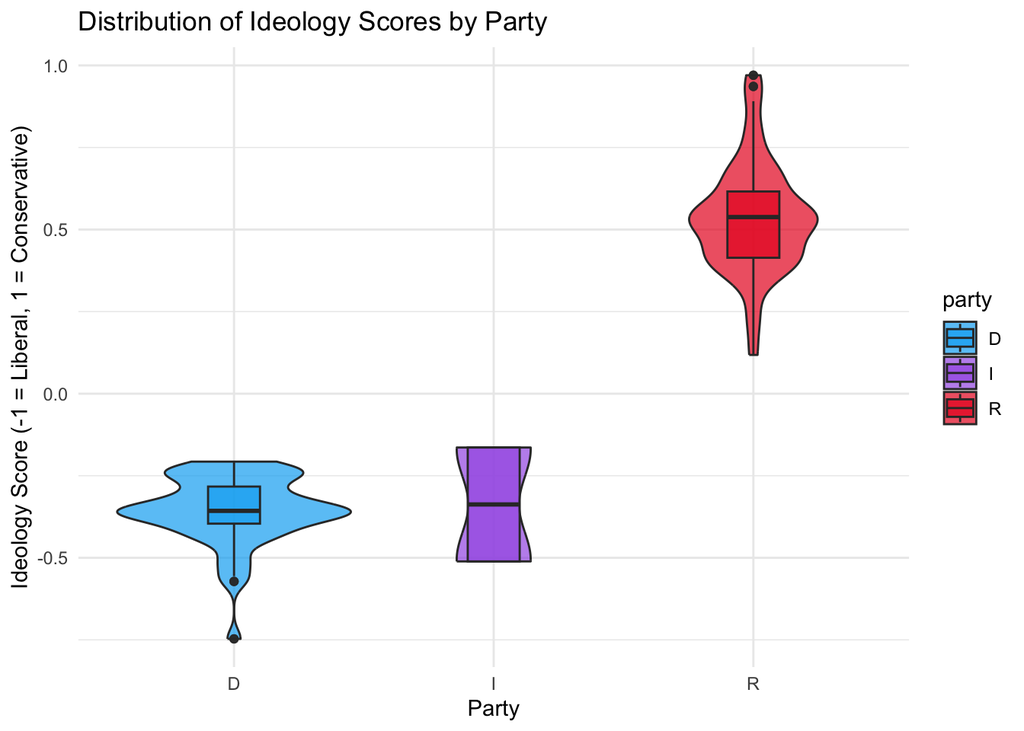

```r
ggplot(df, aes(x = party, y = ideology_score, fill = party)) +
  geom_violin(alpha = 0.7) +
  geom_boxplot(width = 0.2, alpha = 0.7) +
  scale_fill_manual(values = c("D" = "#00AEF3",
                              "R" = "#E81B23",
                              "I" = "#A45FE6")) +
  labs(title = "Distribution of Ideology Scores by Party",
       x = "Party",
       y = "Ideology Score (-1 = Liberal, 1 = Conservative)") +
  theme_minimal()
```

Democrat senators exhibit a more concentrated liberal ideology and Republicans displaying a wider range of ideology scores.

```r
medians <- df %>%
  group_by(party) %>%
  summarise(median_ideology_score = median(ideology_score, na.rm = TRUE))

print(medians)
```

```
# A tibble: 3 × 2
  party median_ideology_score
  <chr>                 <dbl>
1 D                    -0.357
2 I                    -0.338
3 R                     0.538
```

The median ideology score for Democratic (D) senators is -0.357, which falls within the moderately liberal range. The median ideology score for Independent (I) senators is -0.338, which is very close to the Democratic senators and also falls within the moderately liberal range. The median ideology score for Republican (R) senators is 0.538, which is in the moderately conservative range.

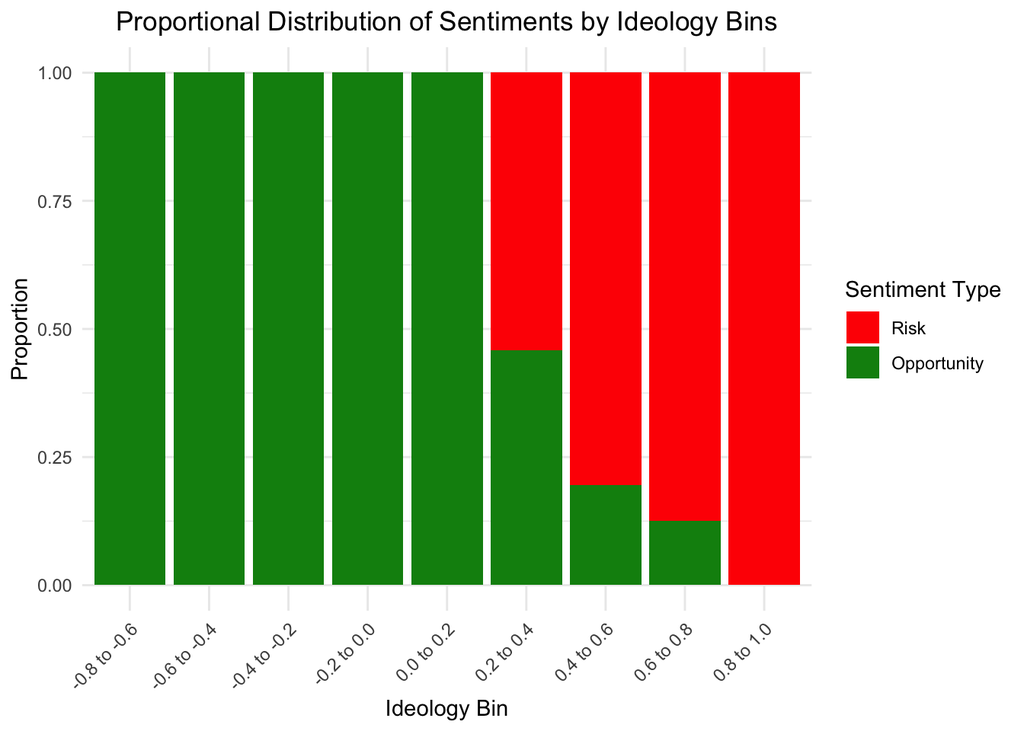

```r
# Create ideology bins
bins <- c(-1.0, -0.8, -0.6, -0.4, -0.2, 0.0, 0.2, 0.4, 0.6, 0.8, 1.0)
labels <- c(
  "-1.0 to -0.8", "-0.8 to -0.6", "-0.6 to -0.4", "-0.4 to -0.2",
  "-0.2 to 0.0", "0.0 to 0.2", "0.2 to 0.4", "0.4 to 0.6",
  "0.6 to 0.8", "0.8 to 1.0"
)

# Add ideology bins and calculate proportions
grouped_data <- df %>%
  filter(!is.na(sentiment)) %>%
  mutate(
    ideology_bin = cut(ideology_score, breaks = bins, labels = labels, include.lowest = TRUE),
    sentiment = factor(sentiment, levels = c(-1, 1), labels = c("Risk", "Opportunity"))
  ) %>%
  group_by(ideology_bin, sentiment) %>%
  summarise(Count = n(), .groups = 'drop') %>%
  group_by(ideology_bin) %>%
  mutate(Proportion = Count / sum(Count))

# Mosaic Plot for Ideology Bins
ggplot(grouped_data, aes(x = ideology_bin, y = Proportion, fill = sentiment)) +
  geom_bar(stat = "identity", position = "fill") +
  scale_fill_manual(values = c("Risk" = "red", "Opportunity" = "#078d0f")) +
  labs(
    title = "Proportional Distribution of Sentiments by Ideology Bins",
    x = "Ideology Bin",
    y = "Proportion",
    fill = "Sentiment Type"
  ) +
  theme_minimal() +
  theme(
    axis.text.x = element_text(angle = 45, hjust = 1),
    legend.position = "right",
    plot.title = element_text(hjust = 0.5)
  )
```

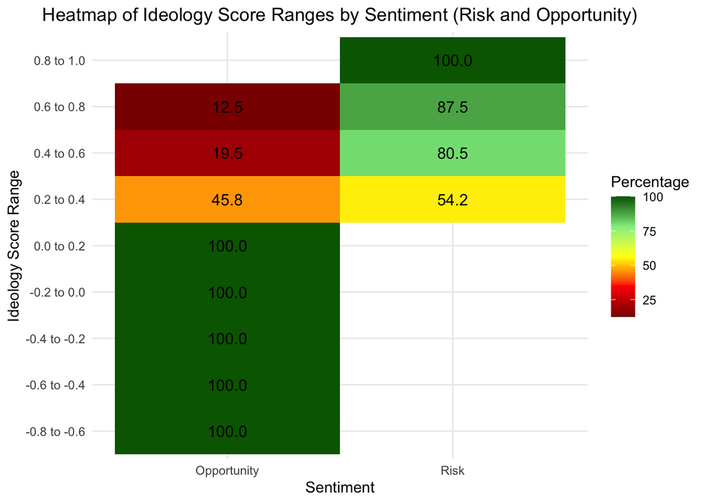

```r
heatmap_data <- df %>%
  mutate(
    ideology_bin = cut(ideology_score,
                      breaks = seq(-1, 1, by = 0.2),
                      labels = c("-1.0 to -0.8",
                               "-0.8 to -0.6",
                               "-0.6 to -0.4",
                               "-0.4 to -0.2",
                               "-0.2 to 0.0",
                               "0.0 to 0.2",
                               "0.2 to 0.4",
                               "0.4 to 0.6",
                               "0.6 to 0.8",
                               "0.8 to 1.0")),
    sentiment = ifelse(sentiment == 1, "Opportunity", "Risk")
  ) %>%
  group_by(ideology_bin, sentiment) %>%
  summarise(count = n(), .groups = "drop") %>%
  group_by(ideology_bin) %>%
  mutate(percentage = (count / sum(count)) * 100) %>%
  ungroup()

heatmap_data <- heatmap_data %>%
  filter(!is.na(ideology_bin))

# Heatmap
ggplot(heatmap_data, aes(x = sentiment, y = ideology_bin, fill = percentage)) +
  geom_tile() +
  geom_text(aes(label = sprintf("%.1f", percentage)),
            color = "black", size = 4) +
  scale_fill_gradientn(
    colors = c("darkred", "red", "yellow", "lightgreen", "darkgreen"),
    values = scales::rescale(c(0, 25, 50, 75, 100))
  ) +
  labs(
    title = "Heatmap of Ideology Score Ranges by Sentiment (Risk and Opportunity)",
    x = "Sentiment",
    y = "Ideology Score Range",
    fill = "Percentage"
  ) +
  theme_minimal() +
  theme(
    axis.text.x = element_text(angle = 0, hjust = 0.5),
    axis.text.y = element_text(hjust = 1),
    plot.title = element_text(hjust = 0.5)
  )
```

Senators with more liberal ideology scores overwhelmingly demonstrate an opportunity based sentiment. In contrast, as the ideology scores become more conservative, the risk sentiment starts to dominate, suggesting a more cautious or skeptical perspective. To confirm this relationship between ideology and sentiment, a correlation analysis would be beneficial.

```r
# Correlation test between ideology score and sentiment
ideology_correlation <- cor.test(df$ideology_score, df$sentiment)
print("\nCorrelation between Ideology Score and Sentiment:")
```

```
[1] "\nCorrelation between Ideology Score and Sentiment:"
```

```r
print(ideology_correlation)
```

```
    Pearson's product-moment correlation

data:  df$ideology_score and df$sentiment
t = -24.182, df = 299, p-value < 2.2e-16
alternative hypothesis: true correlation is not equal to 0
95 percent confidence interval:
 -0.8484613 -0.7713119
sample estimates:
       cor
-0.8134339
```

The results of the correlation analysis provide strong evidence to support the observed relationship between ideology and sentiment. The correlation coefficient is -0.813, indicating a negative correlation between these two variables.

Let’s do some analysis by region now, starting with some maps.

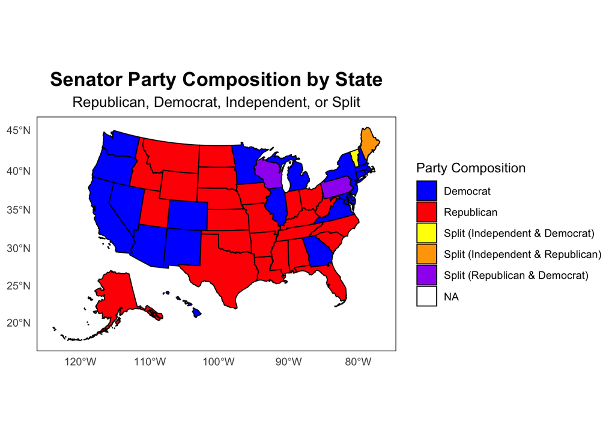

```r
df <- read.csv("../Data/processed-data/Senators_sentiment.csv")

library(dplyr)
library(usmap)
library(ggplot2)

df <- df %>%
  mutate(state = tolower(state.name[match(state, state.abb)]))

state_senators <- df %>%
  distinct(state, party) %>%
  group_by(state) %>%
  summarise(
    party_composition = case_when(
      all(party == "R") ~ "Republican",
      all(party == "D") ~ "Democrat",
      any(party == "I") & all(party %in% c("I", "D")) ~ "Split (Independent & Democrat)",
      any(party == "I") & all(party %in% c("I", "R")) ~ "Split (Independent & Republican)",
      TRUE ~ "Split (Republican & Democrat)"
    ),
    .groups = "drop"
  )

state_senators <- state_senators[!is.na(state_senators$party_composition), ]

party_colors <- c(
  "Republican" = "red",
  "Democrat" = "blue",
  "Split (Independent & Democrat)" = "yellow",
  "Split (Independent & Republican)" = "orange",
  "Split (Republican & Democrat)" = "purple"
)

# Plot Map
plot_usmap(data = state_senators, values = "party_composition", regions = "states") +
  scale_fill_manual(
    values = party_colors,
    name = "Party Composition",
    na.value = "white"
  ) +
  labs(
    title = "Senator Party Composition by State",
    subtitle = "Republican, Democrat, Independent, or Split"
  ) +
  theme_minimal() +
  theme(
    legend.position = "right",
    plot.title = element_text(hjust = 0.5, size = 16, face = "bold"),
    plot.subtitle = element_text(hjust = 0.5, size = 12),
    panel.background = element_rect(fill = "white"),
    panel.grid = element_blank()
  )
```

Most states elect senators from the same party, with the exception of Wisconsin, Pennsylvania, Maine, and Vermont.

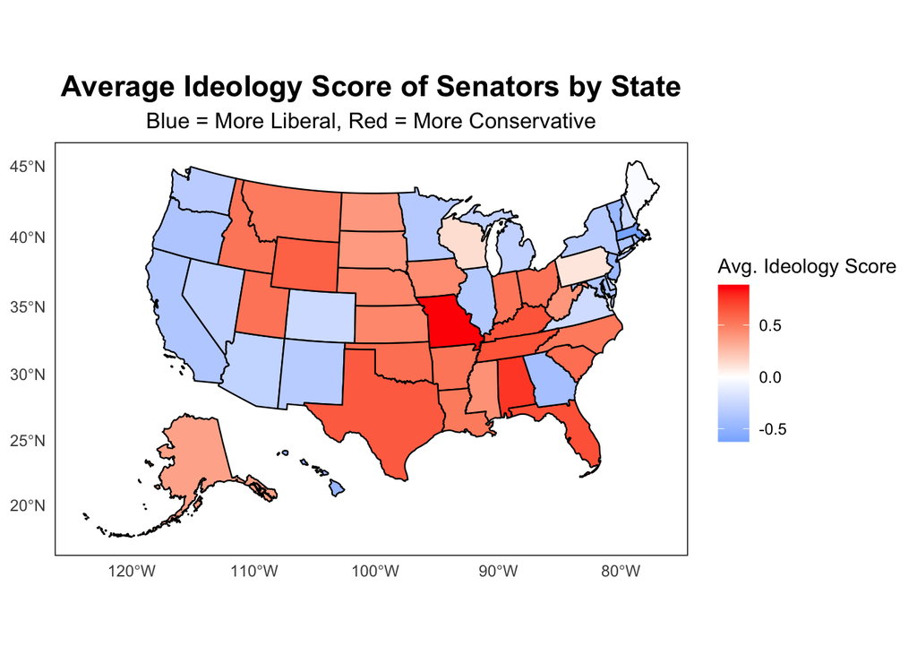

```r
df <- read.csv("../Data/processed-data/Senators_sentiment.csv")

df <- df %>%
  mutate(state = tolower(state.name[match(state, state.abb)]))

state_senators <- df %>%
  group_by(state) %>%
  summarise(
    avg_ideology_score = mean(ideology_score, na.rm = TRUE),
    .groups = "drop"
  )

plot_usmap(data = state_senators, values = "avg_ideology_score", regions = "states") +
  scale_fill_gradient2(
    low = "#3097ff",   # Liberal (-1)
    mid = "white",  # Neutral (0)
    high = "red",    # Conservative (1)
    midpoint = 0,    # Center the gradient around 0
    name = "Avg. Ideology Score"
  ) +
  labs(
    title = "Average Ideology Score of Senators by State",
    subtitle = "Blue = More Liberal, Red = More Conservative"
  ) +
  theme_minimal() +
  theme(
    legend.position = "right",
    plot.title = element_text(hjust = 0.5, size = 16, face = "bold"),
    plot.subtitle = element_text(hjust = 0.5, size = 12),
    panel.background = element_rect(fill = "white"),
    panel.grid = element_blank()
  )
```

The map shows that most states have senators with more moderate ideological leanings, reflecting a balance of Democratic and Republican views. However, a few states have senators with more extreme liberal or conservative positions. This ideological polarization in those states could make it harder for their senators to find common ground and work together on climate change.

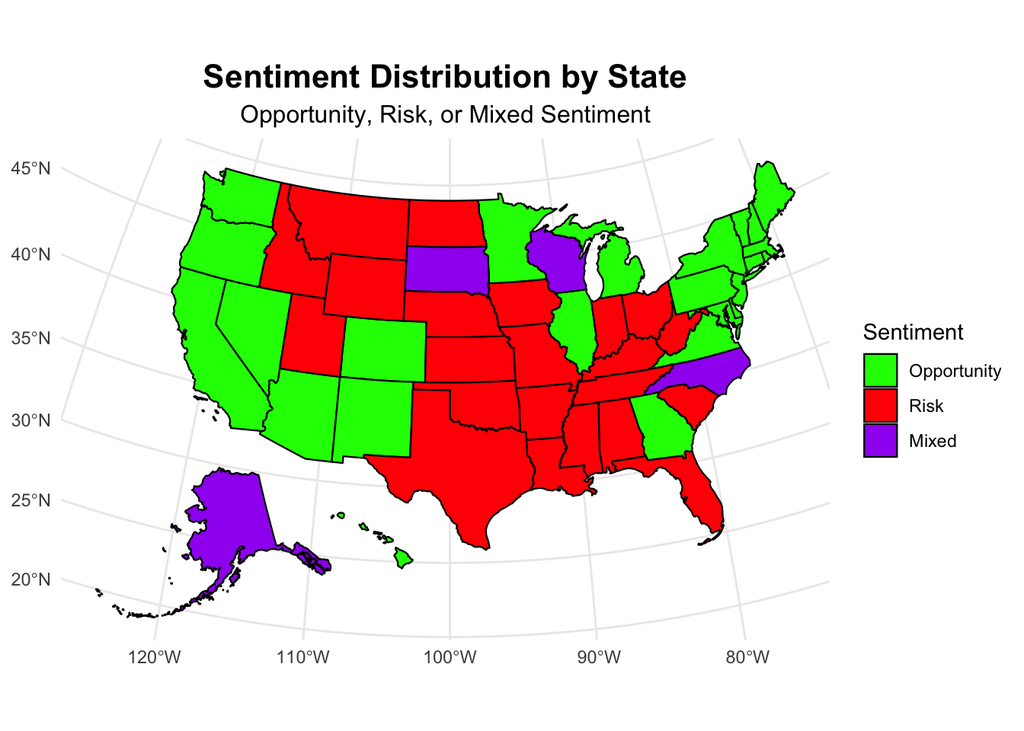

```r
df <- read.csv("../Data/processed-data/Senators_sentiment.csv")

state_sentiment <- df %>%
  filter(!is.na(sentiment)) %>%
  group_by(state, sentiment) %>%
  summarise(count = n(), .groups = "drop") %>%
  group_by(state) %>%
  mutate(
    total = sum(count),
    proportion = count / total
  ) %>%
  summarise(
    max_proportion = max(proportion),
    sentiment_label = case_when(
      max_proportion < 0.6 ~ "mixed",
      sentiment[which.max(proportion)] == -1 ~ "risk",
      sentiment[which.max(proportion)] == 1 ~ "opportunity"
    ),
    .groups = "drop"
  )

# Plot the US map with mixed sentiment
plot_usmap(data = state_sentiment, values = "sentiment_label", regions = "states") +
  scale_fill_manual(
    values = c(
      "opportunity" = "green",
      "risk" = "red",
      "mixed" = "purple"
    ),
    name = "Sentiment",
    breaks = c("opportunity", "risk", "mixed"),
    labels = c("Opportunity", "Risk", "Mixed")
  ) +
  labs(
    title = "Sentiment Distribution by State",
    subtitle = "Opportunity, Risk, or Mixed Sentiment"
  ) +
  theme_minimal() +
  theme(
    legend.position = "right",
    plot.title = element_text(hjust = 0.5, size = 16, face = "bold"),
    plot.subtitle = element_text(hjust = 0.5, size = 12)
  )
```

Wisconsin had mixed senators, one republican and one democrat, and and had an average ideology score of around 0 since it was shaded white in the previous plot. On this plot, we see that it has mixed sentiment which makes sense. Alaska has mixed sentiment because despite both senators being republican, Lisa Murkowski is a strong supporter of combating climate change in Alaska. She says that she has seen the devastating effects climate change has had on the state. Meanwhile, Dan Sullivan often talks about the United States prioritizing climate change over other issues, claiming that climate change is not as important. This is risky sentiment because he is not acknowledging how serious climate change is. South Dakota and North Carolina also have mixed sentiment.

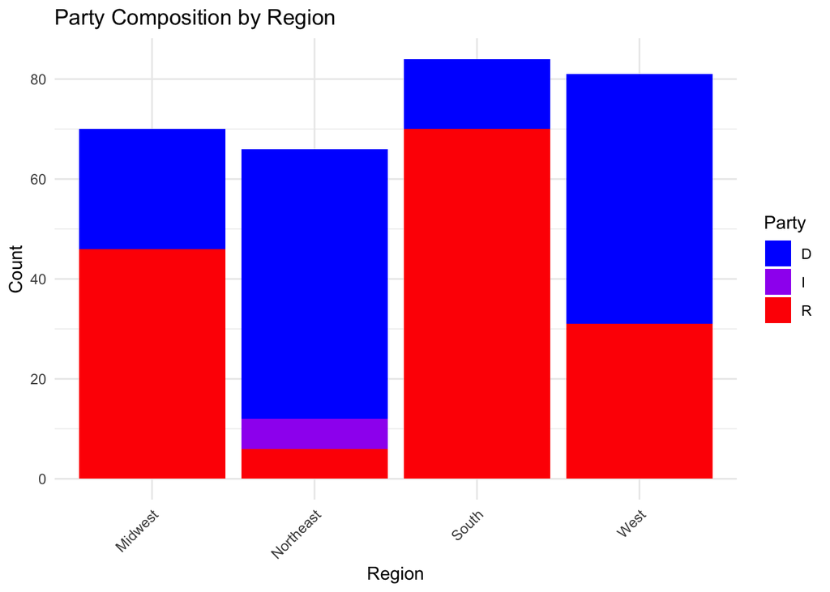

```r
# Region and Party
party_region_counts <- df %>%
  group_by(region, party) %>%
  summarise(Count = n(), .groups = "drop")

ggplot(party_region_counts, aes(x = region, y = Count, fill = party)) +
  geom_bar(stat = "identity") +
  scale_fill_manual(values = c("D" = "blue", "R" = "red", "I" = "purple")) +
  labs(
    title = "Party Composition by Region",
    x = "Region",
    y = "Count",
    fill = "Party"
  ) +
  theme_minimal() +
  theme(
    axis.text.x = element_text(angle = 45, hjust = 1)
  )
```

Northeast and West regions are more Democratic than Republican and Midwest and South regions are more Republican than Democratic.

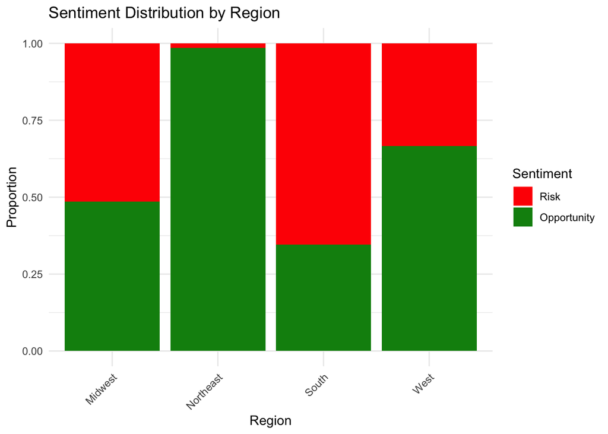

```r
# Region and Sentiment
sentiment_region_props <- df %>%
  group_by(region, sentiment) %>%
  summarise(Count = n(), .groups = "drop") %>%
  group_by(region) %>%
  mutate(Proportion = Count / sum(Count))

ggplot(sentiment_region_props, aes(x = region, y = Proportion, fill = as.factor(sentiment))) +
  geom_bar(stat = "identity", position = "fill") +
  scale_fill_manual(values = c("-1" = "red", "1" = "#078d0f"), labels = c("Risk", "Opportunity")) +
  labs(
    title = "Sentiment Distribution by Region",
    x = "Region",
    y = "Proportion",
    fill = "Sentiment"
  ) +
  theme_minimal() +
  theme(
    axis.text.x = element_text(angle = 45, hjust = 1)
  )
```

Northeast and West regions are more opportunity than risk and Midwest and South regions are more risk than opportunity.

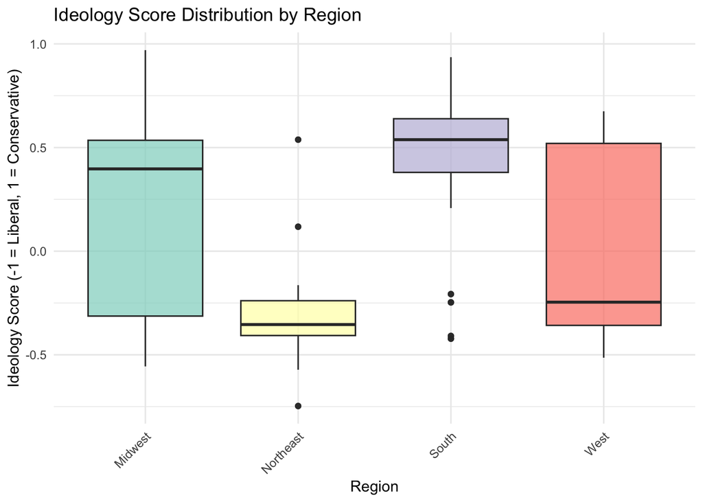

```r
# Boxplot for ideology score by region
ggplot(df, aes(x = region, y = ideology_score, fill = region)) +
  geom_boxplot(alpha = 0.7) +
  scale_fill_brewer(palette = "Set3") +
  labs(
    title = "Ideology Score Distribution by Region",
    x = "Region",
    y = "Ideology Score (-1 = Liberal, 1 = Conservative)"
  ) +
  theme_minimal() +
  theme(
    axis.text.x = element_text(angle = 45, hjust = 1),
    legend.position = "none"
  )
```

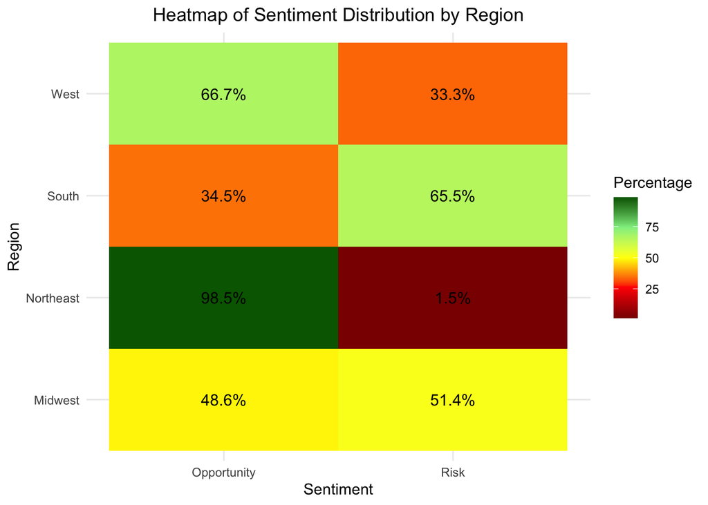

```r
heatmap_data <- df %>%
  mutate(
    sentiment = ifelse(sentiment == 1, "Opportunity", "Risk")
  ) %>%
  group_by(region, sentiment) %>%
  summarise(count = n(), .groups = "drop") %>%
  group_by(region) %>%
  mutate(percentage = (count / sum(count)) * 100) %>%
  ungroup()

# Heatmap
ggplot(heatmap_data, aes(x = sentiment, y = region, fill = percentage)) +
  geom_tile() +
  geom_text(aes(label = sprintf("%.1f%%", percentage)),
            color = "black", size = 4) +
  scale_fill_gradientn(
    colors = c("darkred", "red", "yellow", "lightgreen", "darkgreen"),
    values = scales::rescale(c(0, 25, 50, 75, 100)),
    name = "Percentage"
  ) +
  labs(
    title = "Heatmap of Sentiment Distribution by Region",
    x = "Sentiment",
    y = "Region"
  ) +
  theme_minimal() +
  theme(
    axis.text.x = element_text(angle = 0, hjust = 0.5),
    axis.text.y = element_text(hjust = 1),
    plot.title = element_text(hjust = 0.5)
  )
```

```r
flows_region <- df %>%
  mutate(
    sentiment_label = ifelse(sentiment == 1, "Opportunity", "Risk")
  ) %>%
  group_by(region, sentiment_label) %>%
  summarise(value = n(), .groups = "drop")

nodes_region <- data.frame(
  name = c(
    unique(flows_region$region),
    unique(flows_region$sentiment_label)
  )
)

links_region <- flows_region %>%
  mutate(
    source = match(region, nodes_region$name) - 1,
    target = match(sentiment_label, nodes_region$name) - 1,
    value = value
  )

sankeyNetwork(
  Links = links_region,
  Nodes = nodes_region,
  Source = "source",
  Target = "target",
  Value = "value",
  NodeID = "name",
  sinksRight = TRUE,
  nodeWidth = 30,
  fontSize = 12,
  height = 600,
  width = 1000
)
```

```
Links is a tbl_df. Converting to a plain data frame.
```

[interactive chart not shown]

```r
flows_region <- df %>%
  mutate(
    sentiment_label = ifelse(sentiment == 1, "Opportunity", "Risk")
  ) %>%
  group_by(region, sentiment_label) %>%
  summarise(value = n(), .groups = "drop")

nodes_region <- data.frame(
  name = c(
    unique(flows_region$region),
    unique(flows_region$sentiment_label)
  )
)

links_region <- flows_region %>%
  mutate(
    source = match(region, nodes_region$name) - 1,
    target = match(sentiment_label, nodes_region$name) - 1,
    value = value
  )

sankeyNetwork(
  Links = links_region,
  Nodes = nodes_region,
  Source = "source",
  Target = "target",
  Value = "value",
  NodeID = "name",
  sinksRight = TRUE,
  nodeWidth = 30,
  fontSize = 12,
  height = 600,
  width = 1000
)
```

```
Links is a tbl_df. Converting to a plain data frame.
```

[interactive chart not shown]

```r
# Correlation test between ideology score and sentiment
ideology_correlation <- cor.test(df$ideology_score, df$sentiment)
print("\nCorrelation between Ideology Score and Sentiment:")
```

```
[1] "\nCorrelation between Ideology Score and Sentiment:"
```

```r
print(ideology_correlation)
```

```
    Pearson's product-moment correlation

data:  df$ideology_score and df$sentiment
t = -24.182, df = 299, p-value < 2.2e-16
alternative hypothesis: true correlation is not equal to 0
95 percent confidence interval:
 -0.8484613 -0.7713119
sample estimates:
       cor
-0.8134339
```

The correlation coefficient of -0.813 indicates a strong negative correlation between these two variables. This means that as a senator’s ideology score increases, their sentiment tends to shift towards perceiving climate change in a risky way rather than an opportunistic way.

## Conclusion

The analysis reveals a divide in how U.S. senators view climate change. Democrats and Independents tend to see it in an opportunistic way, while Republicans are more likely to view it in a risky way. This divide is reflected in the negative correlation between a senator’s ideology and their climate sentiment. The regional analysis shows the Northeast and West are more opportunity-focused, while the Midwest and South have a mix of risky and opportunistic perspectives. Some states have a more balanced, “mixed” sentiment, suggesting potential for bipartisan cooperation.